# Introduction to R

Clay Curry

9/5/2021

# Basic Syntax

The statistical programming language **R** uses *functions* to perform operations on *vectors* of atomic data types (including Numeric, Character, Logical, Complex, Raw).

```r
# Comments start with number symbols.

# You can't make multi-line comments,
# but you can stack multiple comments like so.

# in Windows you can use CTRL-ENTER to execute a line.
# on Mac it is COMMAND-ENTER
```

# Stuff you can do without understanding anything about programming

In this section, we show off some of the cool stuff you can do in R without understanding anything about programming. Do not worry about understanding everything the code does. Just enjoy!

## Explore Pre-Loaded Data Sets

### Rivers

The following data set contains lengths of major north american rivers,

```r
data()          # browse pre-loaded data sets
data(rivers)    # get this one: "Lengths of Major North American Rivers"
ls()            # notice that "rivers" now appears in the workspace
```

```
## [1] "rivers"
```

```r
head(rivers)    # peek at the data set
```

```
## [1] 735 320 325 392 524 450
```

```r
length(rivers)  # how many rivers were measured?
```

```
## [1] 141
```

```r
summary(rivers) # what are some summary statistics?
```

```
##    Min. 1st Qu.  Median    Mean 3rd Qu.    Max.
##   135.0   310.0   425.0   591.2   680.0  3710.0
```

```r
# make a stem-and-leaf plot (a histogram-like data visualization)
stem(rivers)
```

```
##
##   The decimal point is 2 digit(s) to the right of the |
##
##    0 | 4
##    2 | 011223334555566667778888899900001111223333344455555666688888999
##    4 | 111222333445566779001233344567
##    6 | 000112233578012234468
##    8 | 045790018
##   10 | 04507
##   12 | 1471
##   14 | 56
##   16 | 7
##   18 | 9
##   20 |
##   22 | 25
##   24 | 3
##   26 |
##   28 |
##   30 |
##   32 |
##   34 |
##   36 | 1
```

```r
# Take this, Bell curve fundamentalists.
stem(log(rivers)) # Notice that the data are neither normal nor log-normal!
```

```
##
##   The decimal point is 1 digit(s) to the left of the |
##
##   48 | 1
##   50 |
##   52 | 15578
##   54 | 44571222466689
##   56 | 023334677000124455789
##   58 | 00122366666999933445777
##   60 | 122445567800133459
##   62 | 112666799035
##   64 | 00011334581257889
##   66 | 003683579
##   68 | 0019156
##   70 | 079357
##   72 | 89
##   74 | 84
##   76 | 56
##   78 | 4
##   80 |
##   82 | 2
```

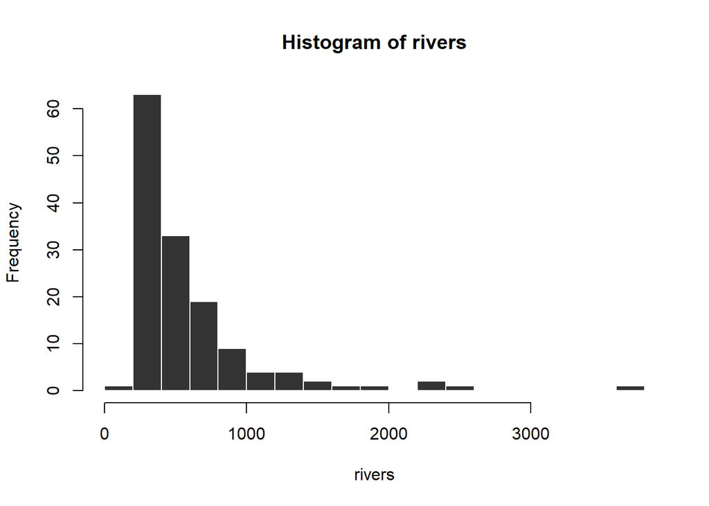

```r
# make a histogram:
hist(rivers, col="#333333", border="white", breaks=25) # play around with these parameters
```

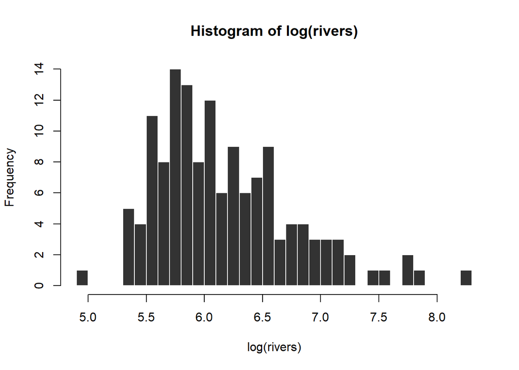

```r
hist(log(rivers), col="#333333", border="white", breaks=25) # you'll do more plotting later
```

### Discoveries

A time series of 100 values, where each entry denotes the number of “great” inventions and scientific discoveries in each year from 1860 to 1959. The World Almanac and Book of Facts, 1975 Edition, pages 315–318.

```r
summary(discoveries)
```

```
##    Min. 1st Qu.  Median    Mean 3rd Qu.    Max.
##     0.0     2.0     3.0     3.1     4.0    12.0
```

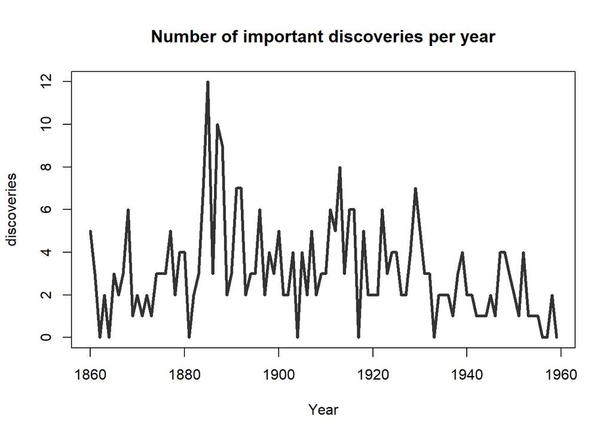

```r
data(discoveries)
plot(discoveries, col="#333333", lwd=3, xlab="Year",
     main="Number of important discoveries per year")
```

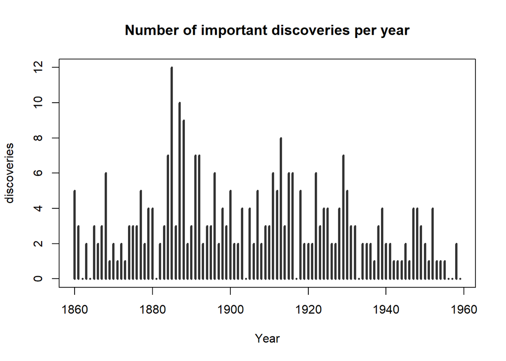

```r
plot(discoveries, col="#333333", lwd=3, type = "h", xlab="Year",
     main="Number of important discoveries per year")
```

```r
# Rather than leaving the default ordering (by year),
# we could also sort to see what's typical:
sort(discoveries)
```

```
##   [1]  0  0  0  0  0  0  0  0  0  1  1  1  1  1  1  1  1  1  1  1  1  2  2  2  2
##  [26]  2  2  2  2  2  2  2  2  2  2  2  2  2  2  2  2  2  2  2  2  2  2  3  3  3
##  [51]  3  3  3  3  3  3  3  3  3  3  3  3  3  3  3  3  3  4  4  4  4  4  4  4  4
##  [76]  4  4  4  4  5  5  5  5  5  5  5  6  6  6  6  6  6  7  7  7  7  8  9 10 12
```

```r
stem(discoveries, scale=2)
```

```
##
##   The decimal point is at the |
##
##    0 | 000000000
##    1 | 000000000000
##    2 | 00000000000000000000000000
##    3 | 00000000000000000000
##    4 | 000000000000
##    5 | 0000000
##    6 | 000000
##    7 | 0000
##    8 | 0
##    9 | 0
##   10 | 0
##   11 |
##   12 | 0
```

```r
max(discoveries)
```

```
## [1] 12
```

# R Functions for Probability Distributions

Every distribution that R handles has four functions. There is a root name, for example, the root name for the normal distribution is `norm`. This root is prefixed by one of the letters,

For notation,

- q - quantile - denotes the cutting points partitioning the domain of a probability distribution into continuous intervals with equal probabilities
- c.d.f. - cumulative distribution function - denotes the probability that a randomly selected element will take a value less than or equal to a quantile
- density function - p.f. or p.d.f. - probability that a randomly selected element will take on an exact value (discrete) or the difference-quotient of the c.d.f.

|  | name | arg | desc |
| --- | --- | --- | --- |
| p- | “probabiliy” | (q, mean=0, sd=1, lower.tail=TRUE, log.p=FALSE) | the cumulative distribution function |
| q- | “quantile” | (p, mean=0, sd=1, lower.tail=TRUE, log.p=FALSE) | the inverse c. d. f. |
| d- | “density” | (x, mean=0, sd=1, log=FALSE) | the density function (p.f. or p.d.f.) |
| r- | “random” | (n, mean=0, sd=1) | a random sample selected from the distribution |

```r
# Roll a die a few times
round(runif(7, min=.5, max=6.5))
```

```
## [1] 4 4 5 3 4 1 1
```

```r
# Draw from a standard Gaussian 9 times
rnorm(9)
```

```
## [1] -0.72676914 -1.58048474 -1.16037442  0.98044931 -0.91625316  0.22656340
## [7]  0.30107482  0.05204064 -1.34918033
```

### Normal Distribution

```r
require(graphics)

dnorm(0) == 1/sqrt(2*pi)
```

```
## [1] TRUE
```

```r
dnorm(1) == exp(-1/2)/sqrt(2*pi)
```

```
## [1] TRUE
```

```r
dnorm(1) == 1/sqrt(2*pi*exp(1))
```

```
## [1] TRUE
```

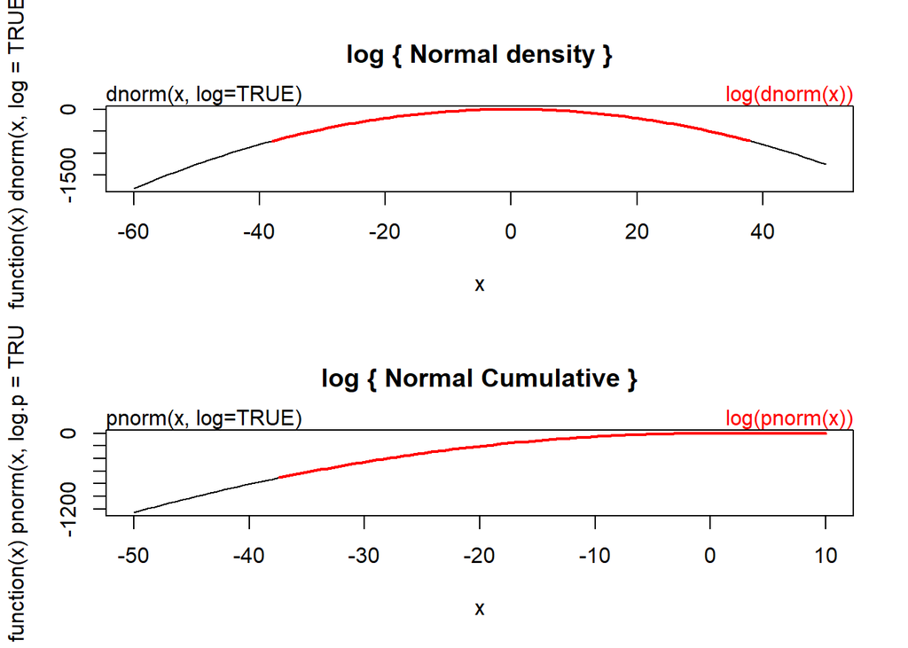

```r
## Using "log = TRUE" for an extended range :
par(mfrow = c(2,1))
plot(function(x) dnorm(x, log = TRUE), -60, 50,
     main = "log { Normal density }")
curve(log(dnorm(x)), add = TRUE, col = "red", lwd = 2)
mtext("dnorm(x, log=TRUE)", adj = 0)
mtext("log(dnorm(x))", col = "red", adj = 1)

plot(function(x) pnorm(x, log.p = TRUE), -50, 10,
     main = "log { Normal Cumulative }")
curve(log(pnorm(x)), add = TRUE, col = "red", lwd = 2)
mtext("pnorm(x, log=TRUE)", adj = 0)
mtext("log(pnorm(x))", col = "red", adj = 1)
```

```r
## if you want the so-called 'error function'
erf <- function(x) 2 * pnorm(x * sqrt(2)) - 1
## (see Abramowitz and Stegun 29.2.29)
## and the so-called 'complementary error function'
erfc <- function(x) 2 * pnorm(x * sqrt(2), lower = FALSE)
## and the inverses
erfinv <- function (x) qnorm((1 + x)/2)/sqrt(2)
erfcinv <- function (x) qnorm(x/2, lower = FALSE)/sqrt(2)
```

# Data types and basic arithmetic

Now for the programming-oriented part of the tutorial. In this section you will meet the important data types of R: integers, numerics, characters, logicals, and factors. There are others, but these are the bare minimum you need to get started.

#### INTEGERS

```r
# Long-storage integers are written with L
5L # 5
```

```
## [1] 5
```

```r
# (Try ?class for more information on the class() function.)
# In R, every single value, like 5L, is considered a vector of length 1
class(5L) # "integer"
```

```
## [1] "integer"
```

```r
length(5L) # 1
```

```
## [1] 1
```

```r
# You can have an integer vector with length > 1 too:
c(4L, 5L, 8L, 3L) # 4 5 8 3
```

```
## [1] 4 5 8 3
```

```r
length(c(4L, 5L, 8L, 3L)) # 4
```

```
## [1] 4
```

```r
class(c(4L, 5L, 8L, 3L)) # "integer"
```

```
## [1] "integer"
```

#### NUMERICS

```r
# A "numeric" is a double-precision floating-point number
5 # 5
```

```
## [1] 5
```

```r
class(5) # "numeric"
```

```
## [1] "numeric"
```

```r
# Again, everything in R is a vector;
# you can make a numeric vector with more than one element
c(3,3,3,2,2,1) # 3 3 3 2 2 1
```

```
## [1] 3 3 3 2 2 1
```

```r
# You can use scientific notation too
5e4 # 50000
```

```
## [1] 50000
```

```r
6.02e23 # Avogadro's number
```

```
## [1] 6.02e+23
```

```r
1.6e-35 # Planck length
```

```
## [1] 1.6e-35
```

```r
# You can also have infinitely large or small numbers
class(Inf)  # "numeric"
```

```
## [1] "numeric"
```

```r
class(-Inf) # "numeric"
```

```
## [1] "numeric"
```

```r
# You might use "Inf", for example, in integrate(dnorm, 3, Inf);
# this obviates Z-score tables.
```

#### BASIC ARITHMETIC

You can do arithmetic with numbers. Doing arithmetic on a mix of integers and numeric gives you another numeric.

```r
10L + 66L # 76      # integer plus integer gives integer
```

```
## [1] 76
```

```r
53.2 - 4  # 49.2    # numeric minus numeric gives numeric
```

```
## [1] 49.2
```

```r
2.0 * 2L  # 4       # numeric times integer gives numeric
```

```
## [1] 4
```

```r
3L / 4    # 0.75    # integer over numeric gives numeric
```

```
## [1] 0.75
```

```r
3 %% 2    # 1       # the remainder of two numerics is another numeric
```

```
## [1] 1
```

```r
# Illegal arithmetic yields you a "not-a-number":
0 / 0 # NaN
```

```
## [1] NaN
```

```r
class(NaN) # "numeric"
```

```
## [1] "numeric"
```

```r
# You can do arithmetic on two vectors with length greater than 1,
# so long as the larger vector's length is an integer multiple of the smaller
c(1,2,3) + c(1,2,3) # 2 4 6
```

```
## [1] 2 4 6
```

```r
# Since a single number is a vector of length one, scalars are applied
# elementwise to vectors
(4 * c(1,2,3) - 2) / 2 # 1 3 5
```

```
## [1] 1 3 5
```

```r
# Except for scalars, use caution when performing arithmetic on vectors with
# different lengths. Although it can be done,
c(1,2,3,1,2,3) * c(1,2) # 1 4 3 2 2 6
```

```
## [1] 1 4 3 2 2 6
```

```r
# Matching lengths is better practice and easier to read
c(1,2,3,1,2,3) * c(1,2,1,2,1,2)
```

```
## [1] 1 4 3 2 2 6
```

#### CHARACTERS

There’s no difference between strings and characters in R

```r
"Horatio" # "Horatio"
```

```
## [1] "Horatio"
```

```r
class("Horatio") # "character"
```

```
## [1] "character"
```

```r
class('H') # "character"
```

```
## [1] "character"
```

```r
# Those were both character vectors of length 1
# Here is a longer one:
c('alef', 'bet', 'gimmel', 'dalet', 'he')
```

```
## [1] "alef"   "bet"    "gimmel" "dalet"  "he"
```

```r
# =>
# "alef"   "bet"    "gimmel" "dalet"  "he"
length(c("Call","me","Ishmael")) # 3
```

```
## [1] 3
```

```r
# You can do regex operations on character vectors:
substr("Fortuna multis dat nimis, nulli satis.", 9, 15) # "multis "
```

```
## [1] "multis "
```

```r
gsub('u', 'ø', "Fortuna multis dat nimis, nulli satis.") # "Fortøna møltis dat nimis, nølli satis."
```

```
## [1] "Fortøna møltis dat nimis, nølli satis."
```

```r
# R has several built-in character vectors:
letters
```

```
##  [1] "a" "b" "c" "d" "e" "f" "g" "h" "i" "j" "k" "l" "m" "n" "o" "p" "q" "r" "s"
## [20] "t" "u" "v" "w" "x" "y" "z"
```

```r
month.abb
```

```
##  [1] "Jan" "Feb" "Mar" "Apr" "May" "Jun" "Jul" "Aug" "Sep" "Oct" "Nov" "Dec"
```

#### LOGICALS

In R, a “logical” is a boolean.

```r
class(TRUE) # "logical"
```

```
## [1] "logical"
```

```r
class(FALSE)    # "logical"
```

```
## [1] "logical"
```

```r
# Their behavior is normal
TRUE == TRUE    # TRUE
```

```
## [1] TRUE
```

```r
TRUE == FALSE   # FALSE
```

```
## [1] FALSE
```

```r
FALSE != FALSE  # FALSE
```

```
## [1] FALSE
```

```r
FALSE != TRUE   # TRUE
```

```
## [1] TRUE
```

```r
# Missing data (NA) is logical, too
class(NA)   # "logical"
```

```
## [1] "logical"
```

```r
# Use | and & for logic operations.
# OR
TRUE | FALSE    # TRUE
```

```
## [1] TRUE
```

```r
# AND
TRUE & FALSE    # FALSE
```

```
## [1] FALSE
```

```r
# Applying | and & to vectors returns elementwise logic operations
c(TRUE,FALSE,FALSE) | c(FALSE,TRUE,FALSE) # TRUE TRUE FALSE
```

```
## [1]  TRUE  TRUE FALSE
```

```r
c(TRUE,FALSE,TRUE) & c(FALSE,TRUE,TRUE) # FALSE FALSE TRUE
```

```
## [1] FALSE FALSE  TRUE
```

```r
# You can test if x is TRUE
isTRUE(TRUE)    # TRUE
```

```
## [1] TRUE
```

```r
# Here we get a logical vector with many elements:
c('Z', 'o', 'r', 'r', 'o') == "Zorro" # FALSE FALSE FALSE FALSE FALSE
```

```
## [1] FALSE FALSE FALSE FALSE FALSE
```

```r
c('Z', 'o', 'r', 'r', 'o') == "Z" # TRUE FALSE FALSE FALSE FALSE
```

```
## [1]  TRUE FALSE FALSE FALSE FALSE
```

#### FACTORS

The factor class is for categorical data. Factors can be ordered (like childrens’ grade levels) or unordered (like colors)

```r
factor(c("blue", "blue", "green", NA, "blue"))
```

```
## [1] blue  blue  green <NA>  blue
## Levels: blue green
```

```r
#  blue blue green   <NA>   blue
# Levels: blue green
# The "levels" are the values the categorical data can take
# Note that missing data does not enter the levels
levels(factor(c("green", "green", "blue", NA, "blue"))) # "blue" "green"
```

```
## [1] "blue"  "green"
```

```r
# If a factor vector has length 1, its levels will have length 1, too
length(factor("green")) # 1
```

```
## [1] 1
```

```r
length(levels(factor("green"))) # 1
```

```
## [1] 1
```

```r
# Factors are commonly seen in data frames, a data structure we will cover later
data(infert) # "Infertility after Spontaneous and Induced Abortion"
levels(infert$education) # "0-5yrs"  "6-11yrs" "12+ yrs"
```

```
## [1] "0-5yrs"  "6-11yrs" "12+ yrs"
```

#### NULL

“NULL” is a weird one; use it to “blank out” a vector

```r
class(NULL) # NULL
```

```
## [1] "NULL"
```

```r
parakeet = c("beak", "feathers", "wings", "eyes")
parakeet
```

```
## [1] "beak"     "feathers" "wings"    "eyes"
```

```r
# =>
# [1] "beak"     "feathers" "wings"    "eyes"
parakeet <- NULL
parakeet
```

[output not shown]

#### TYPE COERCION

Type-coercion is when you force a value to take on a different type

```r
as.character(c(6, 8)) # "6" "8"
```

```
## [1] "6" "8"
```

```r
as.logical(c(1,0,1,1)) # TRUE FALSE  TRUE  TRUE
```

```
## [1]  TRUE FALSE  TRUE  TRUE
```

```r
# If you put elements of different types into a vector, weird coercions happen:
c(TRUE, 4) # 1 4
```

```
## [1] 1 4
```

```r
c("dog", TRUE, 4) # "dog"  "TRUE" "4"
```

```
## [1] "dog"  "TRUE" "4"
```

```r
as.numeric("Bilbo")
```

```
## [1] NA
```

Also note: those were just the basic data types. There are many more data types, such as for dates, time series, etc.

# Variables, loops, if/else

A variable is like a box you store a value in for later use. We call this “assigning” the value to the variable. # Having variables lets us write loops, functions, and if/else statements

## VARIABLES

Lots of way to assign stuff:

```r
x = 5 # this is possible
y <- "1" # this is preferred
TRUE -> z # this works but is weird

# LOOPS
# We've got for loops
for (i in 1:4) {
  print(i)
}
```

```
## [1] 1
## [1] 2
## [1] 3
## [1] 4
```

```r
# We've got while loops
a <- 10
while (a > 4) {
    cat(a, "...", sep = "")
    a <- a - 1
}
```

```
## 10...9...8...7...6...5...
```

```r
# Keep in mind that for and while loops run slowly in R
# Operations on entire vectors (i.e. a whole row, a whole column)
# or apply()-type functions (we'll discuss later) are preferred

# IF/ELSE
# Again, pretty standard
if (4 > 3) {
    print("4 is greater than 3")
} else {
    print("4 is not greater than 3")
}
```

```
## [1] "4 is greater than 3"
```

```r
# FUNCTIONS
# Defined like so:
jiggle <- function(x) {
    x = x + rnorm(1, sd=.1) #add in a bit of (controlled) noise
    return(x)
}
# Called like any other R function:
jiggle(5)   # 5±ε. After set.seed(2716057), jiggle(5)==5.005043
```

```
## [1] 4.979753
```

# Data structures: Vectors, matrices, data frames, and arrays

```r
# ONE-DIMENSIONAL

# Let's start from the very beginning, and with something you already know: vectors.
vec <- c(8, 9, 10, 11)
vec #  8  9 10 11
# We ask for specific elements by subsetting with square brackets
# (Note that R starts counting from 1)
vec[1]      # 8
letters[18] # "r"
LETTERS[13] # "M"
month.name[9]   # "September"
c(6, 8, 7, 5, 3, 0, 9)[3]   # 7
# We can also search for the indices of specific components,
which(vec %% 2 == 0)    # 1 3
# grab just the first or last few entries in the vector,
head(vec, 1)    # 8
tail(vec, 2)    # 10 11
# or figure out if a certain value is in the vector
any(vec == 10) # TRUE
# If an index "goes over" you'll get NA:
vec[6]  # NA
# You can find the length of your vector with length()
length(vec) # 4
# You can perform operations on entire vectors or subsets of vectors
vec * 4 # 16 20 24 28
vec[2:3] * 5    # 25 30
any(vec[2:3] == 8) # FALSE
# and R has many built-in functions to summarize vectors
mean(vec)   # 9.5
var(vec)    # 1.666667
sd(vec)     # 1.290994
max(vec)    # 11
min(vec)    # 8
sum(vec)    # 38
# Some more nice built-ins:
5:15    # 5  6  7  8  9 10 11 12 13 14 15
seq(from=0, to=31337, by=1337)
# =>
#  [1]     0  1337  2674  4011  5348  6685  8022  9359 10696 12033 13370 14707
# [13] 16044 17381 18718 20055 21392 22729 24066 25403 26740 28077 29414 30751

# TWO-DIMENSIONAL (ALL ONE CLASS)

# You can make a matrix out of entries all of the same type like so:
mat <- matrix(nrow = 3, ncol = 2, c(1,2,3,4,5,6))
mat
# =>
#      [,1] [,2]
# [1,]    1    4
# [2,]    2    5
# [3,]    3    6
# Unlike a vector, the class of a matrix is "matrix", no matter what's in it
class(mat) # => "matrix"
# Ask for the first row
mat[1,] # 1 4
# Perform operation on the first column
3 * mat[,1] # 3 6 9
# Ask for a specific cell
mat[3,2]    # 6

# Transpose the whole matrix
t(mat)
# =>
#      [,1] [,2] [,3]
# [1,]    1    2    3
# [2,]    4    5    6

# Matrix multiplication
mat %*% t(mat)
# =>
#      [,1] [,2] [,3]
# [1,]   17   22   27
# [2,]   22   29   36
# [3,]   27   36   45

# cbind() sticks vectors together column-wise to make a matrix
mat2 <- cbind(1:4, c("dog", "cat", "bird", "dog"))
mat2
# =>
#      [,1] [,2]
# [1,] "1"  "dog"
# [2,] "2"  "cat"
# [3,] "3"  "bird"
# [4,] "4"  "dog"
class(mat2) # matrix
# Again, note what happened!
# Because matrices must contain entries all of the same class,
# everything got converted to the character class
c(class(mat2[,1]), class(mat2[,2]))

# rbind() sticks vectors together row-wise to make a matrix
mat3 <- rbind(c(1,2,4,5), c(6,7,0,4))
mat3
# =>
#      [,1] [,2] [,3] [,4]
# [1,]    1    2    4    5
# [2,]    6    7    0    4
# Ah, everything of the same class. No coercions. Much better.

# TWO-DIMENSIONAL (DIFFERENT CLASSES)

# For columns of different types, use a data frame
# This data structure is so useful for statistical programming,
# a version of it was added to Python in the package "pandas".

students <- data.frame(c("Cedric","Fred","George","Cho","Draco","Ginny"),
                       c(3,2,2,1,0,-1),
                       c("H", "G", "G", "R", "S", "G"))
names(students) <- c("name", "year", "house") # name the columns
class(students) # "data.frame"
students
# =>
#     name year house
# 1 Cedric    3     H
# 2   Fred    2     G
# 3 George    2     G
# 4    Cho    1     R
# 5  Draco    0     S
# 6  Ginny   -1     G
class(students$year)    # "numeric"
class(students[,3]) # "factor"
# find the dimensions
nrow(students)  # 6
ncol(students)  # 3
dim(students)   # 6 3
# The data.frame() function converts character vectors to factor vectors
# by default; turn this off by setting stringsAsFactors = FALSE when
# you create the data.frame
?data.frame

# There are many twisty ways to subset data frames, all subtly unalike
students$year   # 3  2  2  1  0 -1
students[,2]    # 3  2  2  1  0 -1
students[,"year"]   # 3  2  2  1  0 -1

# An augmented version of the data.frame structure is the data.table
# If you're working with huge or panel data, or need to merge a few data
# sets, data.table can be a good choice. Here's a whirlwind tour:
install.packages("data.table") # download the package from CRAN
require(data.table) # load it
students <- as.data.table(students)
students # note the slightly different print-out
# =>
#      name year house
# 1: Cedric    3     H
# 2:   Fred    2     G
# 3: George    2     G
# 4:    Cho    1     R
# 5:  Draco    0     S
# 6:  Ginny   -1     G
students[name=="Ginny"] # get rows with name == "Ginny"
# =>
#     name year house
# 1: Ginny   -1     G
students[year==2] # get rows with year == 2
# =>
#      name year house
# 1:   Fred    2     G
# 2: George    2     G
# data.table makes merging two data sets easy
# let's make another data.table to merge with students
founders <- data.table(house=c("G","H","R","S"),
                       founder=c("Godric","Helga","Rowena","Salazar"))
founders
# =>
#    house founder
# 1:     G  Godric
# 2:     H   Helga
# 3:     R  Rowena
# 4:     S Salazar
setkey(students, house)
setkey(founders, house)
students <- founders[students] # merge the two data sets by matching "house"
setnames(students, c("house","houseFounderName","studentName","year"))
students[,order(c("name","year","house","houseFounderName")), with=F]
# =>
#    studentName year house houseFounderName
# 1:        Fred    2     G           Godric
# 2:      George    2     G           Godric
# 3:       Ginny   -1     G           Godric
# 4:      Cedric    3     H            Helga
# 5:         Cho    1     R           Rowena
# 6:       Draco    0     S          Salazar

# data.table makes summary tables easy
students[,sum(year),by=house]
# =>
#    house V1
# 1:     G  3
# 2:     H  3
# 3:     R  1
# 4:     S  0

# To drop a column from a data.frame or data.table,
# assign it the NULL value
students$houseFounderName <- NULL
students
# =>
#    studentName year house
# 1:        Fred    2     G
# 2:      George    2     G
# 3:       Ginny   -1     G
# 4:      Cedric    3     H
# 5:         Cho    1     R
# 6:       Draco    0     S
```

```r
# Drop a row by subsetting
# Using data.table:
students[studentName != "Draco"]
# =>
#    house studentName year
# 1:     G        Fred    2
# 2:     G      George    2
# 3:     G       Ginny   -1
# 4:     H      Cedric    3
# 5:     R         Cho    1
# Using data.frame:
students <- as.data.frame(students)
students[students$house != "G",]
# =>
#   house houseFounderName studentName year
# 4     H            Helga      Cedric    3
# 5     R           Rowena         Cho    1
# 6     S          Salazar       Draco    0

# MULTI-DIMENSIONAL (ALL ELEMENTS OF ONE TYPE)

# Arrays creates n-dimensional tables
# All elements must be of the same type
# You can make a two-dimensional table (sort of like a matrix)
array(c(c(1,2,4,5),c(8,9,3,6)), dim=c(2,4))
# =>
#      [,1] [,2] [,3] [,4]
# [1,]    1    4    8    3
# [2,]    2    5    9    6
# You can use array to make three-dimensional matrices too
array(c(c(c(2,300,4),c(8,9,0)),c(c(5,60,0),c(66,7,847))), dim=c(3,2,2))
# =>
# , , 1
#
#      [,1] [,2]
# [1,]    2    8
# [2,]  300    9
# [3,]    4    0
#
# , , 2
#
#      [,1] [,2]
# [1,]    5   66
# [2,]   60    7
# [3,]    0  847

# LISTS (MULTI-DIMENSIONAL, POSSIBLY RAGGED, OF DIFFERENT TYPES)

# Finally, R has lists (of vectors)
list1 <- list(time = 1:40)
list1$price = c(rnorm(40,.5*list1$time,4)) # random
list1
# You can get items in the list like so
list1$time # one way
list1[["time"]] # another way
list1[[1]] # yet another way
# =>
#  [1]  1  2  3  4  5  6  7  8  9 10 11 12 13 14 15 16 17 18 19 20 21 22 23 24 25 26 27 28 29 30 31 32 33
# [34] 34 35 36 37 38 39 40
# You can subset list items like any other vector
list1$price[4]

# Lists are not the most efficient data structure to work with in R;
# unless you have a very good reason, you should stick to data.frames
# Lists are often returned by functions that perform linear regressions

##################################################
# The apply() family of functions
##################################################

# Remember mat?
mat
# =>
#      [,1] [,2]
# [1,]    1    4
# [2,]    2    5
# [3,]    3    6
# Use apply(X, MARGIN, FUN) to apply function FUN to a matrix X
# over rows (MAR = 1) or columns (MAR = 2)
# That is, R does FUN to each row (or column) of X, much faster than a
# for or while loop would do
apply(mat, MAR = 2, jiggle)
# =>
#      [,1] [,2]
# [1,]    3   15
# [2,]    7   19
# [3,]   11   23
# Other functions: ?lapply, ?sapply

# Don't feel too intimidated; everyone agrees they are rather confusing

# The plyr package aims to replace (and improve upon!) the *apply() family.
install.packages("plyr")
require(plyr)
?plyr



#########################
# Loading data
#########################

# "pets.csv" is a file on the internet
# (but it could just as easily be a file on your own computer)
require(RCurl)
pets <- read.csv(textConnection(getURL("https://learnxinyminutes.com/docs/pets.csv")))
pets
head(pets, 2) # first two rows
tail(pets, 1) # last row

# To save a data frame or matrix as a .csv file
write.csv(pets, "pets2.csv") # to make a new .csv file
# set working directory with setwd(), look it up with getwd()

# Try ?read.csv and ?write.csv for more information



#########################
# Statistical Analysis
#########################

# Linear regression!
linearModel <- lm(price  ~ time, data = list1)
linearModel # outputs result of regression
# =>
# Call:
# lm(formula = price ~ time, data = list1)
#
# Coefficients:
# (Intercept)         time
#      0.1453       0.4943
summary(linearModel) # more verbose output from the regression
# =>
# Call:
# lm(formula = price ~ time, data = list1)
#
# Residuals:
#     Min      1Q  Median      3Q     Max
# -8.3134 -3.0131 -0.3606  2.8016 10.3992
#
# Coefficients:
#             Estimate Std. Error t value Pr(>|t|)
# (Intercept)  0.14527    1.50084   0.097    0.923
# time         0.49435    0.06379   7.749 2.44e-09 ***
# ---
# Signif. codes:  0 ‘***’ 0.001 ‘**’ 0.01 ‘*’ 0.05 ‘.’ 0.1 ‘ ’ 1
#
# Residual standard error: 4.657 on 38 degrees of freedom
# Multiple R-squared:  0.6124,  Adjusted R-squared:  0.6022
# F-statistic: 60.05 on 1 and 38 DF,  p-value: 2.44e-09
coef(linearModel) # extract estimated parameters
# =>
# (Intercept)        time
#   0.1452662   0.4943490
summary(linearModel)$coefficients # another way to extract results
# =>
#              Estimate Std. Error    t value     Pr(>|t|)
# (Intercept) 0.1452662 1.50084246 0.09678975 9.234021e-01
# time        0.4943490 0.06379348 7.74920901 2.440008e-09
summary(linearModel)$coefficients[,4] # the p-values
# =>
#  (Intercept)         time
# 9.234021e-01 2.440008e-09

# GENERAL LINEAR MODELS
# Logistic regression
set.seed(1)
list1$success = rbinom(length(list1$time), 1, .5) # random binary
glModel <- glm(success  ~ time, data = list1,
    family=binomial(link="logit"))
glModel # outputs result of logistic regression
# =>
# Call:  glm(formula = success ~ time,
#   family = binomial(link = "logit"), data = list1)
#
# Coefficients:
# (Intercept)         time
#     0.17018     -0.01321
#
# Degrees of Freedom: 39 Total (i.e. Null);  38 Residual
# Null Deviance:        55.35
# Residual Deviance: 55.12   AIC: 59.12
summary(glModel) # more verbose output from the regression
# =>
# Call:
# glm(formula = success ~ time,
#   family = binomial(link = "logit"), data = list1)

# Deviance Residuals:
#    Min      1Q  Median      3Q     Max
# -1.245  -1.118  -1.035   1.202   1.327
#
# Coefficients:
#             Estimate Std. Error z value Pr(>|z|)
# (Intercept)  0.17018    0.64621   0.263    0.792
# time        -0.01321    0.02757  -0.479    0.632
#
# (Dispersion parameter for binomial family taken to be 1)
#
#     Null deviance: 55.352  on 39  degrees of freedom
# Residual deviance: 55.121  on 38  degrees of freedom
# AIC: 59.121
#
# Number of Fisher Scoring iterations: 3


#########################
# Plots
#########################

# BUILT-IN PLOTTING FUNCTIONS
# Scatterplots!
plot(list1$time, list1$price, main = "fake data")
# Plot regression line on existing plot
abline(linearModel, col = "red")
# Get a variety of nice diagnostics
plot(linearModel)
# Histograms!
hist(rpois(n = 10000, lambda = 5), col = "thistle")
# Barplots!
barplot(c(1,4,5,1,2), names.arg = c("red","blue","purple","green","yellow"))
```

```r
# GGPLOT2
# But these are not even the prettiest of R's plots
# Try the ggplot2 package for more and better graphics
install.packages("ggplot2")
require(ggplot2)
?ggplot2
pp <- ggplot(students, aes(x=house))
pp + geom_bar()
ll <- as.data.table(list1)
pp <- ggplot(ll, aes(x=time,price))
pp + geom_point()
# ggplot2 has excellent documentation (available http://docs.ggplot2.org/current/)
```